# Critical Materials

MME EAB Meeting “7 Minutes of Science” Presentation

Eric Payton

Thursday 6 November 2025

## Critical materials are any non-fuel mineral, element, substance, or material that…

- … has a high risk of supply chain disruption; and
- … serves an essential function in one or more energy technologies (production, transmission, storage, and conservation)

Ref: https://www.federalregister.gov/documents/2023/08/04/2023-16611/notice-of-final-determination-on-2023-doe-critical-materials-list

## Let’s consider them the perspective of the periodic table.

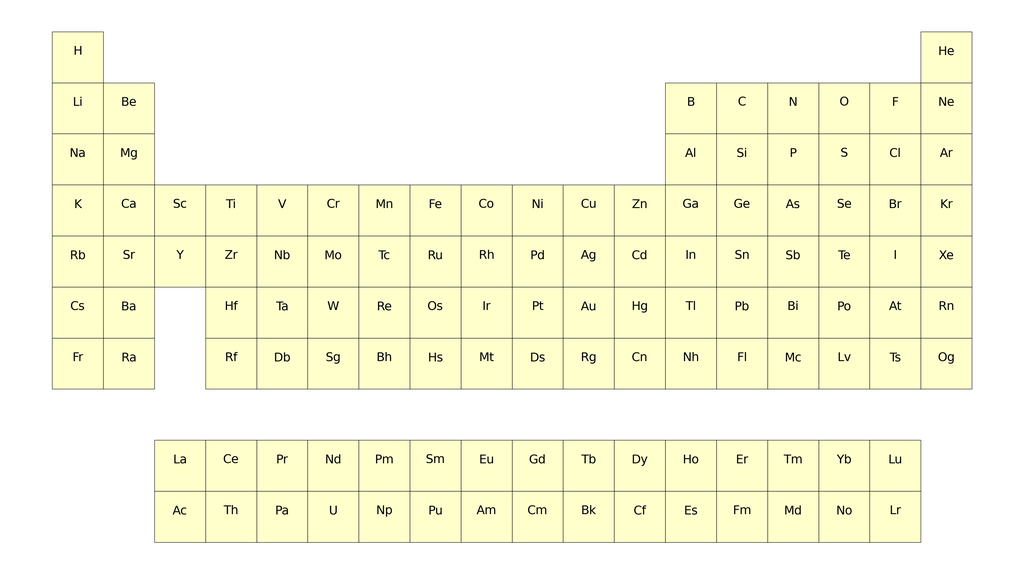

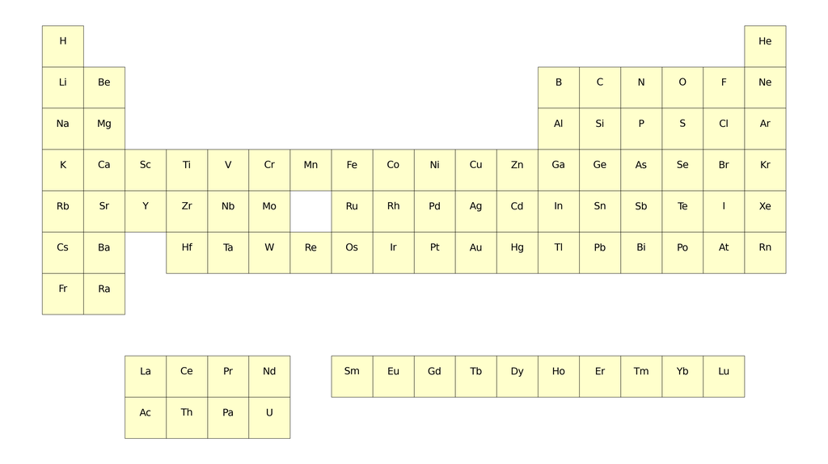

## Some are more abundant in the Earth’s crust than others.

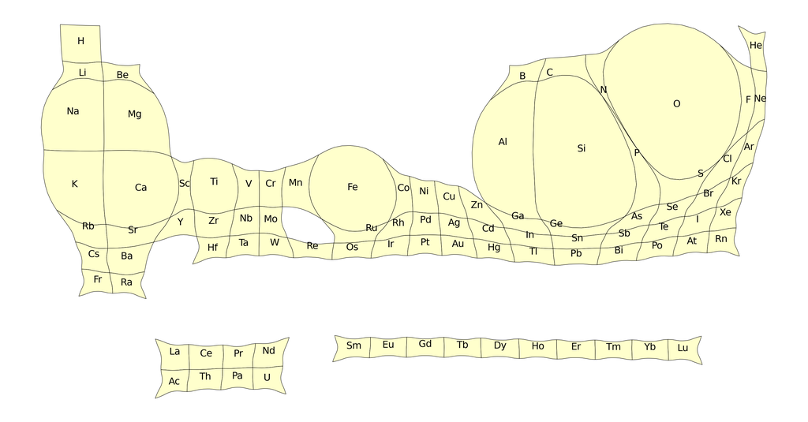

## Natural resources and processing capabilities are geographically concentrated.

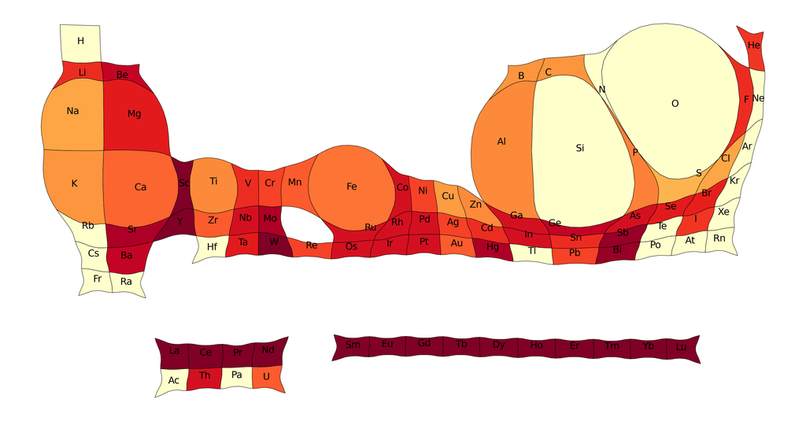

Deeper red indicates greater risk of supply chain disruption.

Ref: 10.1111/j.0033-0124.1985.00075.x

## The USGS identifies 50 minerals as critical to US economic and national security

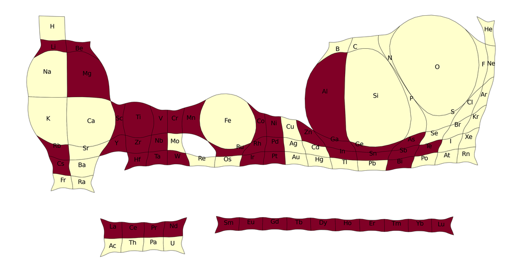

*USGS Critical Minerals not shown on the periodic table: barite, fluorspar, graphite.*

## The US DoE identifies 19 materials as critical to future US energy security

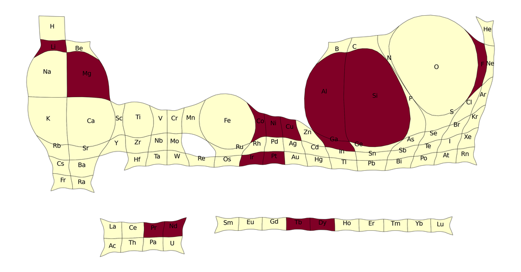

*DoE Critical materials not shown on the periodic table: SiC, e-steel, coal, graphite.*

## Considering these together, a substantial portion of the periodic table is currently critical for the United States.

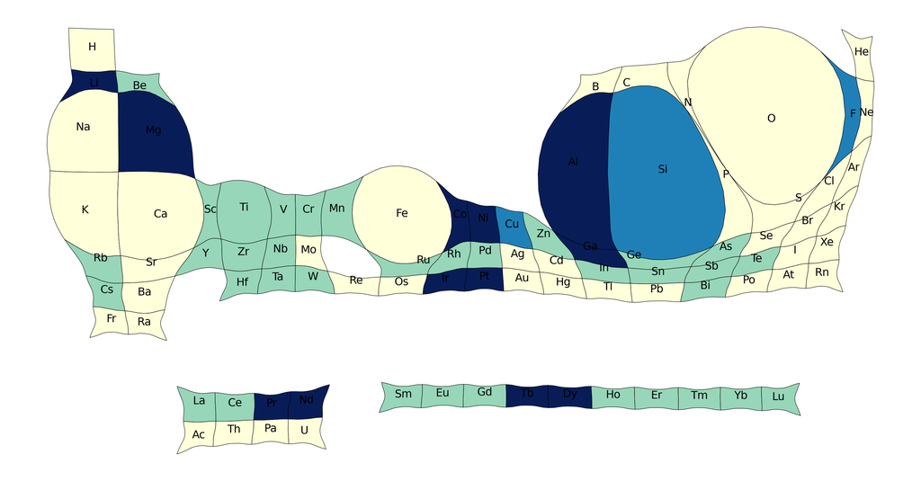

USGS Critical Minerals • DoE Critical Elements • On both lists • Not critical

*DoE Critical materials not shown on the periodic table: SiC, e-steel, coal, graphite; USGS Critical Minerals not shown: barite, fluorspar, graphite*

## While in some cases we lack geological resources, more frequently we lack domestic processing capabilities.

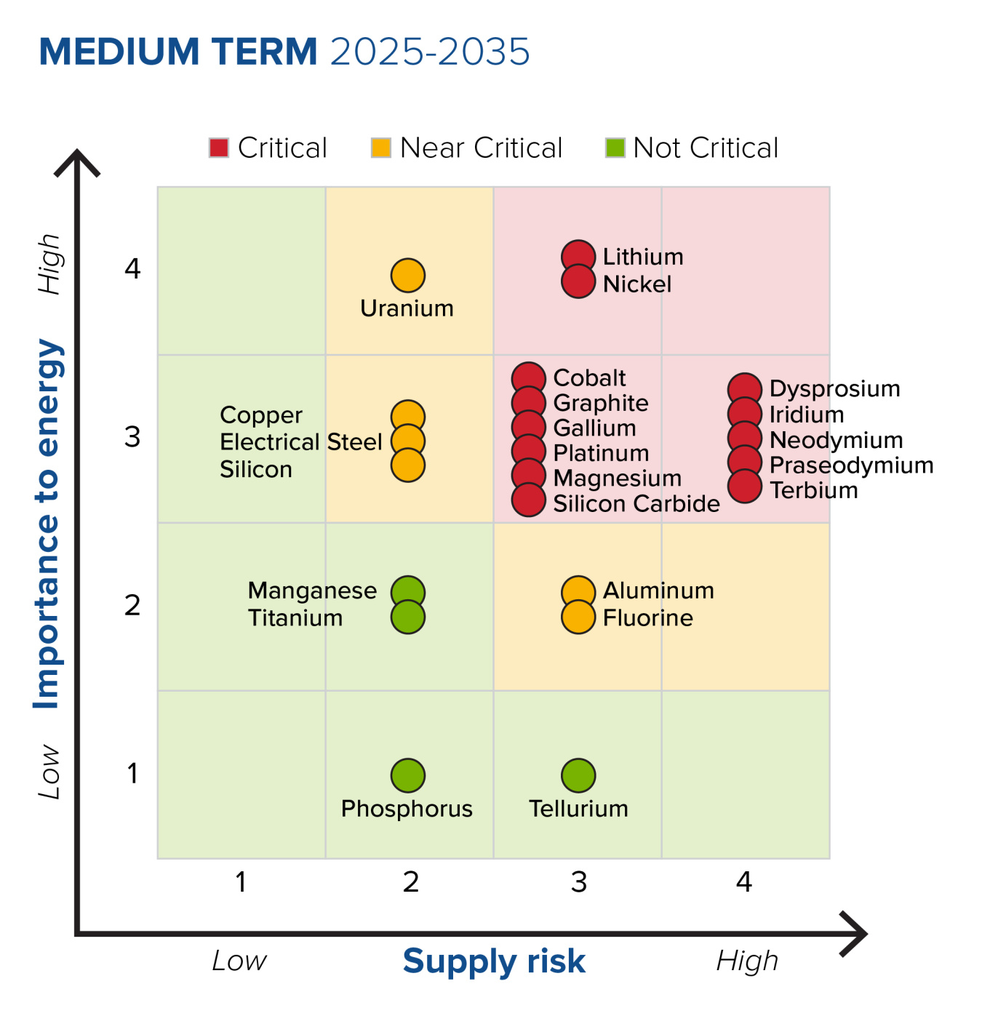

## There are two paths to support the national needs from a mechanical, materials, and industrial engineering research perspective.

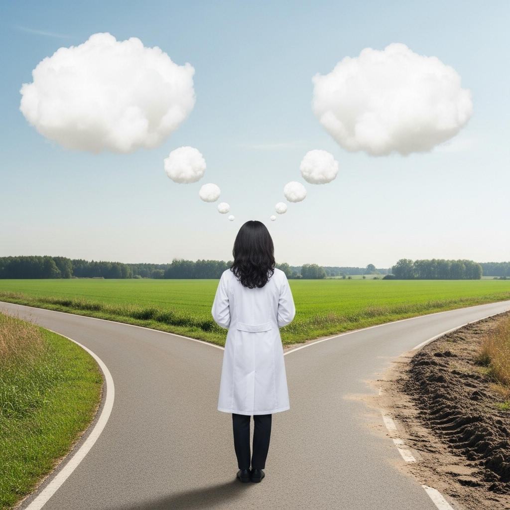

Minimize the amount of critical minerals needed in engineering materials.

Make materials containing critical minerals last longer in service.

For both of these, we must advance the science of *materials processing* and the methodologies of *materials discovery & design*.

# Questions? Further discussion?

Please reach out. paytonej@ucmail.uc.edu